# RMED901 Group 3 report

15-09-2022 to 22-09-2022

This is the report for group 3 in RMED901.

**Reading and loading the data**

We load the necessary packages first.

```r
library(tidyverse)
library(here)
```

```r
library(ggplot2)
```

We read the non tidy version of the data, that we will try to tidy later.

```r
data_nontidy <- read_delim(here("data", "copy_exam_nontidy.txt"))
```

**Exploring the data**

```r
head(data_nontidy)
```

```
## # A tibble: 6 × 15
##   subject gende…¹ clini…² result demo_…³ drive…⁴ ct_re…⁵ order…⁶ payor…⁷ patie…⁸
##   <chr>   <chr>   <chr>   <chr>  <chr>     <dbl>   <dbl>   <dbl> <chr>   <chr>
## 1 6812 b… female… clinic… negat… patient       1      45       1 <NA>    <NA>
## 2 659 be… female… inpati… negat… patient       0      45       0 govern… inpati…
## 3 7575 l… male-34 emerge… negat… patient       0      45       1 commer… observ…
## 4 173 na… female… emerge… negat… patient       0      45       1 commer… inpati…
## 5 10224 … male-4  emerge… negat… patient       0      45       1 govern… observ…
## 6 1021 s… female… emerge… negat… patient       0      45       1 commer… observ…
## # … with 5 more variables: `pan day` <dbl>, `1_test_id` <chr>, row <dbl>,
## #   `time measurement` <chr>, .value <dbl>, and abbreviated variable names
## #   ¹`gender-age`, ²clinic_name, ³demo_group, ⁴drive_thru_ind, ⁵ct_result,
## #   ⁶orderset, ⁷payor_group, ⁸patient_class
## # ℹ Use `colnames()` to see all variable names
```

```r
tail(data_nontidy)
```

```
## # A tibble: 6 × 15
##   subject gende…¹ clini…² result demo_…³ drive…⁴ ct_re…⁵ order…⁶ payor…⁷ patie…⁸
##   <chr>   <chr>   <chr>   <chr>  <chr>     <dbl>   <dbl>   <dbl> <chr>   <chr>
## 1 8741 j… female… clinic… negat… misc a…       1    45         1 <NA>    <NA>
## 2 6190 a… male-4  clinic… negat… patient       1    45         1 <NA>    <NA>
## 3 3324 i… female… emerge… negat… patient       0    45         1 govern… day su…
## 4 2880 n… female… inpati… negat… patient       0    45         1 govern… observ…
## 5 4222 b… female… clinic… posit… misc a…       1    23.7       1 <NA>    <NA>
## 6 8226 e… male-14 clinic… negat… patient       1    45         1 <NA>    <NA>
## # … with 5 more variables: `pan day` <dbl>, `1_test_id` <chr>, row <dbl>,
## #   `time measurement` <chr>, .value <dbl>, and abbreviated variable names
## #   ¹`gender-age`, ²clinic_name, ³demo_group, ⁴drive_thru_ind, ⁵ct_result,
## #   ⁶orderset, ⁷payor_group, ⁸patient_class
## # ℹ Use `colnames()` to see all variable names
```

```r
summary(data_nontidy)
```

```
##    subject           gender-age        clinic_name           result
##  Length:34048       Length:34048       Length:34048       Length:34048
##  Class :character   Class :character   Class :character   Class :character
##  Mode  :character   Mode  :character   Mode  :character   Mode  :character
##
##
##
##
##   demo_group        drive_thru_ind    ct_result        orderset
##  Length:34048       Min.   :0.000   Min.   :14.05   Min.   :0.0000
##  Class :character   1st Qu.:0.000   1st Qu.:45.00   1st Qu.:0.0000
##  Mode  :character   Median :1.000   Median :45.00   Median :1.0000
##                     Mean   :0.514   Mean   :44.12   Mean   :0.6955
##                     3rd Qu.:1.000   3rd Qu.:45.00   3rd Qu.:1.0000
##                     Max.   :1.000   Max.   :45.00   Max.   :1.0000
##                                     NA's   :452
##  payor_group        patient_class         pan day        1_test_id
##  Length:34048       Length:34048       Min.   :  4.00   Length:34048
##  Class :character   Class :character   1st Qu.: 38.00   Class :character
##  Mode  :character   Mode  :character   Median : 65.00   Mode  :character
##                                        Mean   : 63.22
##                                        3rd Qu.: 87.00
##                                        Max.   :107.00
##
##       row        time measurement       .value
##  Min.   :    1   Length:34048       Min.   :  -18.60
##  1st Qu.: 3884   Class :character   1st Qu.:    1.90
##  Median : 7762   Mode  :character   Median :    3.90
##  Mean   : 7764                      Mean   :    6.25
##  3rd Qu.:11643                      3rd Qu.:    5.40
##  Max.   :15524                      Max.   :61370.20
##
```

```r
glimpse(data_nontidy)
```

```
## Rows: 34,048
## Columns: 15
## $ subject            <chr> "6812 bessa tarly", "659 becca umber", "7575 lord s…
## $ `gender-age`       <chr> "female-2", "female-14", "male-34", "female-2", "ma…
## $ clinic_name        <chr> "clinical lab", "inpatient ward i", "emergency dept…
## $ result             <chr> "negative", "negative", "negative", "negative", "ne…
## $ demo_group         <chr> "patient", "patient", "patient", "patient", "patien…
## $ drive_thru_ind     <dbl> 1, 0, 0, 0, 0, 0, 0, 1, 0, 0, 1, 0, 1, 1, 1, 0, 0, …
## $ ct_result          <dbl> 45.00, 45.00, 45.00, 45.00, 45.00, 45.00, 45.00, 45…
## $ orderset           <dbl> 1, 0, 1, 1, 1, 1, 1, 1, 1, 0, 0, 1, 1, 1, 1, 1, 1, …
## $ payor_group        <chr> NA, "government", "commercial", "commercial", "gove…
## $ patient_class      <chr> NA, "inpatient", "observation", "inpatient", "obser…
## $ `pan day`          <dbl> 25, 105, 104, 25, 44, 45, 61, 64, 98, 89, 43, 106, …
## $ `1_test_id`        <chr> "covid", "covid", "covid", "covid", "covid", "covid…
## $ row                <dbl> 1493, 14963, 14855, 1379, 4821, 4877, 7092, 7590, 1…
## $ `time measurement` <chr> "rec_ver_tat", "col_rec_tat", "rec_ver_tat", "col_r…
## $ .value             <dbl> 3.9, 10.1, 6.6, 1.0, 3.6, 0.2, 0.8, 5.9, 6.1, 3.0, …
```

```r
skimr::skim(data_nontidy)
```

Data summary

| Name | data_nontidy |
| --- | --- |
| Number of rows | 34048 |
| Number of columns | 15 |
| _______________________ |  |
| Column type frequency: |  |
| character | 9 |
| numeric | 6 |
| ________________________ |  |
| Group variables | None |

**Variable type: character**

| skim_variable | n_missing | complete_rate | min | max | empty | n_unique | whitespace |
| --- | --- | --- | --- | --- | --- | --- | --- |
| subject | 0 | 1.00 | 11 | 29 | 0 | 12344 | 0 |
| gender-age | 0 | 1.00 | 6 | 10 | 0 | 217 | 0 |
| clinic_name | 0 | 1.00 | 3 | 32 | 0 | 88 | 0 |
| result | 0 | 1.00 | 7 | 8 | 0 | 3 | 0 |
| demo_group | 0 | 1.00 | 6 | 12 | 0 | 5 | 0 |
| payor_group | 15527 | 0.54 | 5 | 18 | 0 | 7 | 0 |
| patient_class | 15506 | 0.54 | 9 | 23 | 0 | 9 | 0 |
| 1_test_id | 0 | 1.00 | 5 | 5 | 0 | 2 | 0 |
| time measurement | 0 | 1.00 | 11 | 11 | 0 | 2 | 0 |

**Variable type: numeric**

| skim_variable | n_missing | complete_rate | mean | sd | p0 | p25 | p50 | p75 | p100 | hist |
| --- | --- | --- | --- | --- | --- | --- | --- | --- | --- | --- |
| drive_thru_ind | 0 | 1.00 | 0.51 | 0.50 | 0.00 | 0.00 | 1.0 | 1.0 | 1.0 | ▇▁▁▁▇ |
| ct_result | 452 | 0.99 | 44.12 | 3.97 | 14.05 | 45.00 | 45.0 | 45.0 | 45.0 | ▁▁▁▁▇ |
| orderset | 0 | 1.00 | 0.70 | 0.46 | 0.00 | 0.00 | 1.0 | 1.0 | 1.0 | ▃▁▁▁▇ |
| pan day | 0 | 1.00 | 63.22 | 27.21 | 4.00 | 38.00 | 65.0 | 87.0 | 107.0 | ▃▇▆▇▇ |
| row | 0 | 1.00 | 7764.03 | 4479.97 | 1.00 | 3883.75 | 7762.5 | 11643.0 | 15524.0 | ▇▇▇▇▇ |
| .value | 0 | 1.00 | 6.25 | 332.79 | -18.60 | 1.90 | 3.9 | 5.4 | 61370.2 | ▇▁▁▁▁ |

There are 15 columns and 34 048 rows in this dataset.

We also noticed that there are 12 344 unique values for subject, which may indicate that there are variables that lead to multiple observations.

In the skim, we saw that there is 15527 missing values for the column payor_group, 15506 for patient_class and 452 for ct_result. This we explored further with the use of gg_miss_var.

```r
naniar::gg_miss_var(data_nontidy)
```

```
## Warning: It is deprecated to specify `guide = FALSE` to remove a guide. Please
## use `guide = "none"` instead.
```

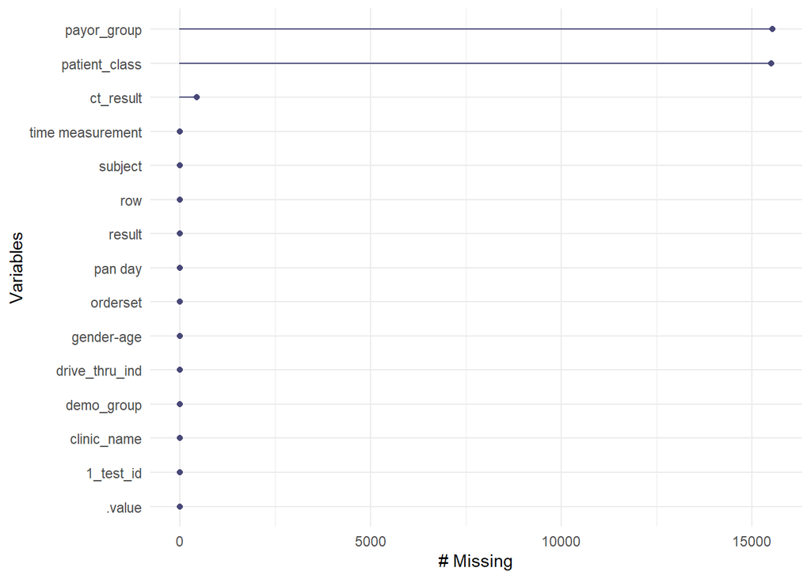

```r
data_tidy<-
  data_nontidy %>%
  rename(value=.value,
         pan_day="pan day")%>%
  separate(col = "gender-age",
           into = c("gender", "age"),
           sep = "-")%>%
  separate(col = subject,
           into = c("id", "first_name", "last_name"),
           sep = " ") %>%
  distinct() %>%
  pivot_wider(names_from = "time measurement", values_from = "value")
```

**Wrangling the data**  
After tidying, we wished to wrangle it to certain specifications. We individually wrote code to:  
-Remove unnecessary columns: row, test_id and demo_group  
-Change the variable types  
-Create a new set of columns showing whether rec_ver_Tat is higher than 100 or not, showing pan_day in weeks, showing drive_thru_ind as Yes/No and showing the multiplication of ct_result and orderset for each person  
-Set the order of columns as: id, age, gender and other columns  
-Arrange ID column to increasing numbers  
-Join an additional dataset to the main dataset

We then took all our individual code and wrote a pipeline which could do all of this with our tidy data, creating a new data-set in the progress: data_wrangled

```r
#Reading the new data
data_join <- read.delim(here("data", "copy_exam_joindata.txt"))
```

```r
#Creating the data_wrangled object
data_wrangled <-
  data_tidy %>%
  select(-row,-"1_test_id", -demo_group) %>%
  mutate(age = as.numeric(age),
         pan_day = as.numeric(pan_day),
         drive_thru_ind = as.numeric(drive_thru_ind),
         ct_result = as.numeric(ct_result),
         id = as.numeric(id)) %>%
  mutate(rec_ver_tat= if_else(rec_ver_tat>=100, "High", "Low")) %>%
  mutate(pan_weeks = pan_day / 7) %>%
  mutate(drive_thru_ind = if_else(drive_thru_ind == 1, "Yes", "No")) %>%
  mutate(ct_order_result = ct_result * orderset) %>%
  select(c(id, age, gender), everything()) %>%
  arrange(id) %>%
  left_join(data_join)
```

**Exploring the data**

In order to explore the wrangled data I am using the same functions used to explore previous data in this script. These functions are glimpse, head, tail and summary.

```r
glimpse(data_wrangled)
```

```
## Rows: 15,524
## Columns: 18
## $ id              <dbl> 1, 1, 2, 2, 2, 2, 3, 3, 3, 3, 3, 4, 4, 4, 5, 5, 5, 6, …
## $ age             <dbl> 29.0, 29.0, 18.0, 18.0, 18.0, 18.0, 1.0, 1.0, 1.0, 1.0…
## $ gender          <chr> "male", "male", "female", "female", "female", "female"…
## $ first_name      <chr> "wyl", "wyl", "mela", "mela", "mela", "mela", "harma",…
## $ last_name       <chr> "harlaw", "harlaw", "tyrell", "tyrell", "tyrell", "tyr…
## $ clinic_name     <chr> "clinical lab", "clinical lab", "inpatient ward o", "e…
## $ result          <chr> "invalid", "negative", "invalid", "negative", "invalid…
## $ drive_thru_ind  <chr> "Yes", "Yes", "No", "No", "No", "No", "No", "No", "No"…
## $ ct_result       <dbl> 45, 45, NA, 45, 45, 45, 45, 45, 45, 45, 45, 45, 45, 45…
## $ orderset        <dbl> 1, 1, 0, 1, 0, 0, 1, 0, 0, 0, 0, 1, 1, 1, 1, 1, 1, 0, …
## $ payor_group     <chr> NA, NA, "commercial", "commercial", "commercial", "com…
## $ patient_class   <chr> NA, NA, "inpatient", "inpatient", "inpatient", "inpati…
## $ pan_day         <dbl> 35, 95, 88, 32, 80, 28, 24, 19, 94, 50, 100, 100, 29, …
## $ rec_ver_tat     <chr> "Low", "Low", "Low", "Low", "Low", "Low", "Low", "Low"…
## $ col_rec_tat     <dbl> 2.0, 3.7, 0.2, 0.3, 0.2, 1.4, 1.0, 2.6, 1.0, 2.6, 0.6,…
## $ pan_weeks       <dbl> 5.000000, 13.571429, 12.571429, 4.571429, 11.428571, 4…
## $ ct_order_result <dbl> 45, 45, NA, 45, 0, 0, 45, 0, 0, 0, 0, 45, 45, 45, NA, …
## $ antibody        <dbl> NA, NA, NA, NA, NA, NA, NA, NA, NA, NA, NA, NA, NA, NA…
```

```r
head(data_wrangled)
```

```
## # A tibble: 6 × 18
##      id   age gender first_name last_name clini…¹ result drive…² ct_re…³ order…⁴
##   <dbl> <dbl> <chr>  <chr>      <chr>     <chr>   <chr>  <chr>     <dbl>   <dbl>
## 1     1    29 male   wyl        harlaw    clinic… inval… Yes          45       1
## 2     1    29 male   wyl        harlaw    clinic… negat… Yes          45       1
## 3     2    18 female mela       tyrell    inpati… inval… No           NA       0
## 4     2    18 female mela       tyrell    emerge… negat… No           45       1
## 5     2    18 female mela       tyrell    inpati… inval… No           45       0
## 6     2    18 female mela       tyrell    inpati… negat… No           45       0
## # … with 8 more variables: payor_group <chr>, patient_class <chr>,
## #   pan_day <dbl>, rec_ver_tat <chr>, col_rec_tat <dbl>, pan_weeks <dbl>,
## #   ct_order_result <dbl>, antibody <dbl>, and abbreviated variable names
## #   ¹clinic_name, ²drive_thru_ind, ³ct_result, ⁴orderset
## # ℹ Use `colnames()` to see all variable names
```

```r
tail(data_wrangled)
```

```
## # A tibble: 6 × 18
##      id   age gender first_name last_name clini…¹ result drive…² ct_re…³ order…⁴
##   <dbl> <dbl> <chr>  <chr>      <chr>     <chr>   <chr>  <chr>     <dbl>   <dbl>
## 1 12341    32 male   arnolf     kettlebl… intl p… negat… No         45         0
## 2 12342    68 female quaithe    tully     clinic… negat… Yes        45         1
## 3 12343    37 male   quhuru     kettlebl… clinic… negat… Yes        45         1
## 4 12344    42 female maerie     bolton    clinic… negat… Yes        45         1
## 5 12345    43 male   raymar     stark     clinic… posit… Yes        30.9       1
## 6 12346    52 male   tormund    harlaw    clinic… posit… Yes        27.4       0
## # … with 8 more variables: payor_group <chr>, patient_class <chr>,
## #   pan_day <dbl>, rec_ver_tat <chr>, col_rec_tat <dbl>, pan_weeks <dbl>,
## #   ct_order_result <dbl>, antibody <dbl>, and abbreviated variable names
## #   ¹clinic_name, ²drive_thru_ind, ³ct_result, ⁴orderset
## # ℹ Use `colnames()` to see all variable names
```

```r
summary(data_wrangled)
```

```
##        id             age            gender           first_name
##  Min.   :    1   Min.   :  0.00   Length:15524       Length:15524
##  1st Qu.: 2330   1st Qu.:  2.00   Class :character   Class :character
##  Median : 5268   Median :  9.00   Mode  :character   Mode  :character
##  Mean   : 5571   Mean   : 14.19
##  3rd Qu.: 8636   3rd Qu.: 18.00
##  Max.   :12346   Max.   :138.00
##
##   last_name         clinic_name           result          drive_thru_ind
##  Length:15524       Length:15524       Length:15524       Length:15524
##  Class :character   Class :character   Class :character   Class :character
##  Mode  :character   Mode  :character   Mode  :character   Mode  :character
##
##
##
##
##    ct_result        orderset      payor_group        patient_class
##  Min.   :14.05   Min.   :0.0000   Length:15524       Length:15524
##  1st Qu.:45.00   1st Qu.:0.0000   Class :character   Class :character
##  Median :45.00   Median :1.0000   Mode  :character   Mode  :character
##  Mean   :44.12   Mean   :0.6952
##  3rd Qu.:45.00   3rd Qu.:1.0000
##  Max.   :45.00   Max.   :1.0000
##  NA's   :209
##     pan_day       rec_ver_tat         col_rec_tat         pan_weeks
##  Min.   :  4.00   Length:15524       Min.   :    0.00   Min.   : 0.5714
##  1st Qu.: 38.00   Class :character   1st Qu.:    0.70   1st Qu.: 5.4286
##  Median : 65.00   Mode  :character   Median :    1.90   Median : 9.2857
##  Mean   : 63.21                      Mean   :    7.22   Mean   : 9.0298
##  3rd Qu.: 87.00                      3rd Qu.:    3.60   3rd Qu.:12.4286
##  Max.   :107.00                      Max.   :61370.20   Max.   :15.2857
##
##  ct_order_result    antibody
##  Min.   : 0.0    Min.   : 21.48
##  1st Qu.: 0.0    1st Qu.: 63.30
##  Median :45.0    Median :103.52
##  Mean   :30.6    Mean   :109.99
##  3rd Qu.:45.0    3rd Qu.:156.95
##  Max.   :45.0    Max.   :199.89
##  NA's   :209     NA's   :15275
```

The exploration of the data shows that the data is much tidyer after the wrangling. Glimpse is showing the 18 columns in the dataset. However when you present it with the functions head and tail, it is easy to see what information belongs to which patient, and it is easy to interpret the dataset.

*Exploring the missing data*

After exploring the data in data_wrangled, we wished to look at the missing data. To do this, we first used the gg_miss_var function.

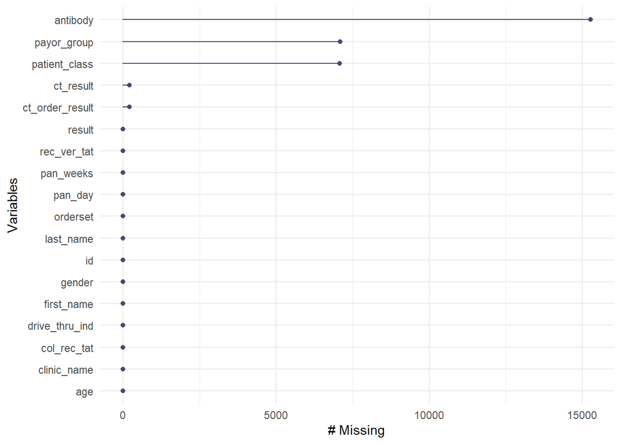

```r
naniar::gg_miss_var(data_wrangled)
```

To get more specific numbers for missing values, we wanted to count up the NAs in each column. To do this, we first filtered by NAs, and afterwards counted the remaining values.

```r
#For payor_group
data_wrangled %>%
  filter(is.na(payor_group))%>%
    count(payor_group)
```

```
## # A tibble: 1 × 2
##   payor_group     n
##   <chr>       <int>
## 1 <NA>         7087
```

```r
#For patient class
data_wrangled %>%
  filter(is.na(patient_class))%>%
    count(patient_class)
```

```
## # A tibble: 1 × 2
##   patient_class     n
##   <chr>         <int>
## 1 <NA>           7077
```

```r
#For ct_result
data_wrangled %>%
  filter(is.na(ct_result))%>%
    count(ct_result)
```

```
## # A tibble: 1 × 2
##   ct_result     n
##       <dbl> <int>
## 1        NA   209
```

In the output, we see that payor_group returns 7087 NA, patient_class returns 7077 NA and ct_result returns 209 NA. When compared to the untidy data, the number of missing values have decreased substantially.

When looking at the values in the dataset, it seems like the patients who tested for covid-19 in clinical labs did not have any data on payor group or patient class.  
To test if this hypothesis was true, we first filtered out by those who were tested in a clinical lab or “line clinical lab”, and then those who had missing values in either patient_class or payor_group.

```r
#Missing payor group values in patients who were tested in a clinical lab
data_wrangled %>%
  filter(clinic_name == "clinical lab") %>%
    filter(is.na(payor_group)) %>%
      count(payor_group)
```

```
## # A tibble: 1 × 2
##   payor_group     n
##   <chr>       <int>
## 1 <NA>         6407
```

```r
data_wrangled %>%
  filter(clinic_name == "line clinical lab-") %>%
    filter(is.na(payor_group)) %>%
      count(payor_group)
```

```
## # A tibble: 1 × 2
##   payor_group     n
##   <chr>       <int>
## 1 <NA>          218
```

```r
#Missing patient class values in patients who were tested in a clinical lab
data_wrangled %>%
  filter(clinic_name == "clinical lab") %>%
    filter(is.na(patient_class)) %>%
      count(patient_class)
```

```
## # A tibble: 1 × 2
##   patient_class     n
##   <chr>         <int>
## 1 <NA>           6406
```

```r
data_wrangled %>%
  filter(clinic_name == "line clinical lab-") %>%
  filter(is.na(patient_class)) %>%
  count(patient_class)
```

```
## # A tibble: 1 × 2
##   patient_class     n
##   <chr>         <int>
## 1 <NA>            218
```

For those tested in a clinical lab, there are 6407 missing values for payor_group and 6406 for patient_class. For the line clinical lab, there are 218 missing values for payor_group and 218 for patient_class.  
The majority of the missing values are therefore connected to the fact that some are tested in a clinical lab.

**Stratifying the data**  
We then stratified the data and reported min, max, mean and sd of a numeric column for a defined set of observations: -Only inpatients  
-Only persons with CT results equal to 45  
-Only those tested after the 50th day of the pandemic  
-Only for those who did not get drive through testing and had a CT result lower than 35

*Only inpatients*  
Since we needed a numeric column we used age to check the min, max, mean and sd.

```r
data_wrangled %>%
  group_by(patient_class =="inpatient") %>%
  summarize(min(age, na.rm = T),max(age, na.rm = T),mean(age, na.rm = T), sd(age, na.rm = T))
```

```
## # A tibble: 3 × 5
##   `patient_class == "inpatient"` `min(age, na.rm = T)` max(age…¹ mean(…² sd(ag…³
##   <lgl>                                          <dbl>     <dbl>   <dbl>   <dbl>
## 1 FALSE                                              0       119   10.2    11.2
## 2 TRUE                                               0       119    5.92    8.71
## 3 NA                                                 0       138   21.0    19.4
## # … with abbreviated variable names ¹`max(age, na.rm = T)`,
## #   ²`mean(age, na.rm = T)`, ³`sd(age, na.rm = T)`
```

*CT result equal to 45*  
This code stratifies the data set based on ct_results equal to 45. The data was summarized based on the minimum, maximum, mean, and standard deviation of the pan_day.

```r
data_wrangled %>%
  filter(ct_result==45) %>%
  summarize(min(pan_day, na.rm = T), max(pan_day, na.rm = T), mean(pan_day, na.rm = T), sd(pan_day, na.rm = T))
```

```
## # A tibble: 1 × 4
##   `min(pan_day, na.rm = T)` `max(pan_day, na.rm = T)` mean(pan_day, na…¹ sd(pa…²
##                       <dbl>                     <dbl>              <dbl>   <dbl>
## 1                         4                       107               63.2    27.2
## # … with abbreviated variable names ¹`mean(pan_day, na.rm = T)`,
## #   ²`sd(pan_day, na.rm = T)`
```

*Tested after day 50*  
Here we have chosen age as the numeric column to check min, max, mean and sd.

```r
data_wrangled %>%
  group_by(pan_day > 50) %>%
  summarise(min(age), max(age), mean(age), sd(age))
```

```
## # A tibble: 2 × 5
##   `pan_day > 50` `min(age)` `max(age)` `mean(age)` `sd(age)`
##   <lgl>               <dbl>      <dbl>       <dbl>     <dbl>
## 1 FALSE                   0        119        8.93      11.9
## 2 TRUE                    0        138       17.2       17.9
```

```r
data_wrangled %>%
  filter(drive_thru_ind == "No"& ct_result < 35) %>%
  head()
```

```
## # A tibble: 6 × 18
##      id   age gender first_name last_name clini…¹ result drive…² ct_re…³ order…⁴
##   <dbl> <dbl> <chr>  <chr>      <chr>     <chr>   <chr>  <chr>     <dbl>   <dbl>
## 1   213  18   female sylva      westerli… emerge… posit… No         30.9       1
## 2   625   0.3 female waif       baratheon emerge… posit… No         22.2       1
## 3   848  44   male   rakharo    kettlebl… hosp o… posit… No         19.7       1
## 4   857   9   male   tomard     lannister emerge… posit… No         21.1       1
## 5   860   2   male   colemon    clegane   picu    posit… No         33.2       0
## 6   860   2   male   colemon    clegane   picu    posit… No         27.3       0
## # … with 8 more variables: payor_group <chr>, patient_class <chr>,
## #   pan_day <dbl>, rec_ver_tat <chr>, col_rec_tat <dbl>, pan_weeks <dbl>,
## #   ct_order_result <dbl>, antibody <dbl>, and abbreviated variable names
## #   ¹clinic_name, ²drive_thru_ind, ³ct_result, ⁴orderset
## # ℹ Use `colnames()` to see all variable names
```

**Creating a table**  
We then created a table from the “gender” and “payor_group” columns.

```r
gender_payor_table <-
  data_wrangled %>%
  with(table(gender, payor_group))
```

```
##         payor_group
## gender   charity care commercial government medical assistance other self pay
##   female            9       1863       1864                 46    13      114
##   male              6       1863       1780                 38     6      102
##         payor_group
## gender   unassigned
##   female        367
##   male          366
```

**Plots**  
We then made a set of plots to investigate some questions:  
-If there were gender differences in frequency of test-taking at drive-through  
-If there were more tests in any of the sex groups  
-If the distribution of ct_result differ with the sex groups  
-If the distribution of ct_result differ with payor_group

*Gender differences in taking the test at a drive-through*  
We made a plot to investigate if there were more females than males that took the test at a drive-through.

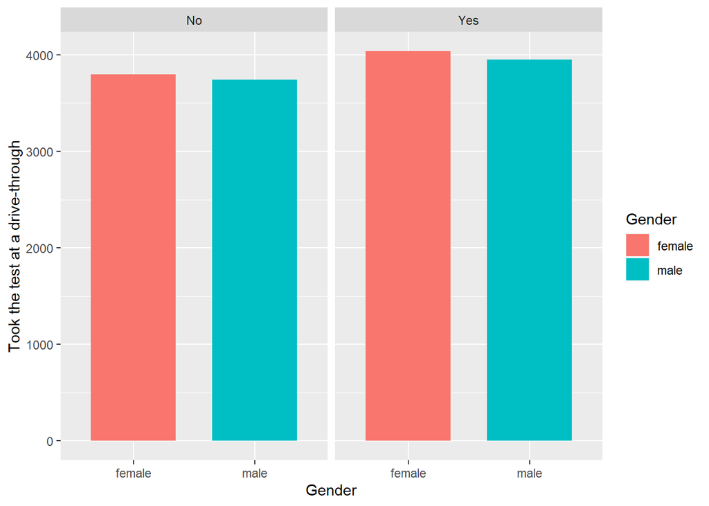

The plot shows that there are slightly more females than males that took the test at a drive through.

*More tests in any sex groups*  
We made a plot for vizualising the number of tests in both sex groups. We interpeted each observation as an independent test, and simply found the quantity of tests done on men and women.

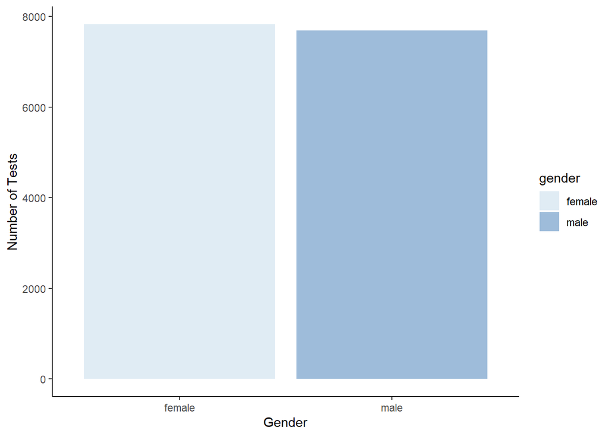

This shows that there is a difference between men and women in number of tests, but that this difference is relatively small with women having slightly more tests.

*Distribution of ct_result in sex groups*  
This plot helps to determine whether there is a difference in the distribution of ct_results based on gender.

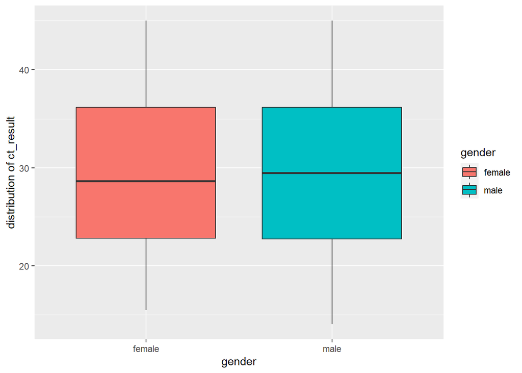

The box plots display the range and the median of ct_result in each group.  
Compared to women, men have a broader range of ct_results. Although the highest number of ct_results belongs to women, the median is higher in men.

*Checking if the distributution of `ct_result` differ with `payor_group`*  
We made a plot in order to see the distribution of ct_results within different payor_groups.

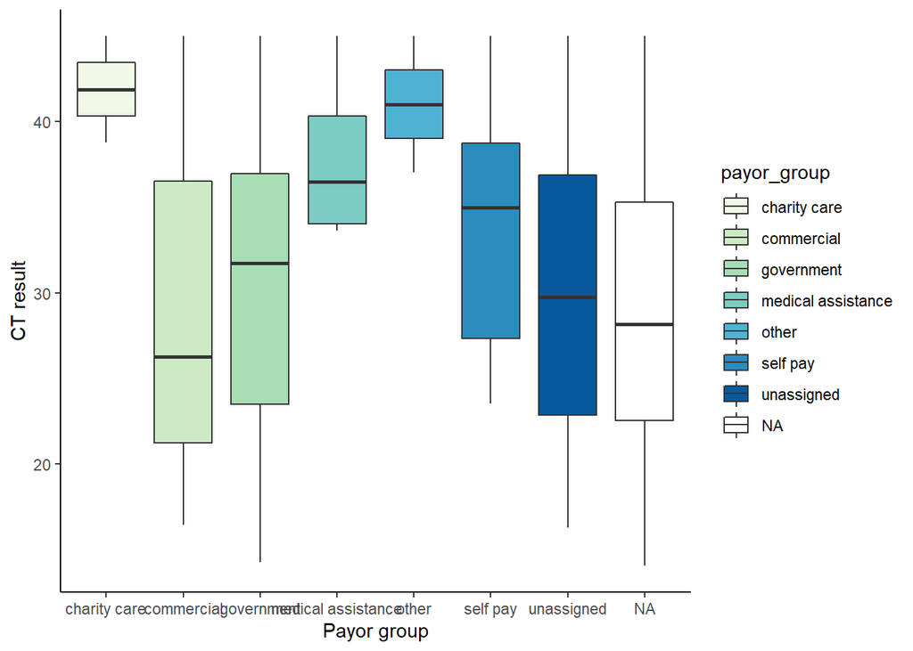

This box plot displays the range and the median of ct_result in each group, and the boxplot displays that the distribution differ between the groups.

**Analysis**  
We then analysed the dataset to investigate different questions:  
-If there was a difference in distributions of CT results between outcome groups  
- If there were more positive tests in the drive-through than elsewhere - If the number of positive tests depend on the pan_day - If there is an association between the age of the individual and the test result

*T-test to find out whether there were more positive tests in the drive-through than elsewhere*  
First, we wanted to look at the number of positive tests in the drive-through vs elsewhere, to see how big of an difference there were.

```r
data_wrangled %>%
  group_by(result == "positive") %>%
  count(drive_thru_ind == "Yes")
```

```
## # A tibble: 4 × 3
## # Groups:   result == "positive" [2]
##   `result == "positive"` `drive_thru_ind == "Yes"`     n
##   <lgl>                  <lgl>                     <int>
## 1 FALSE                  FALSE                      7151
## 2 FALSE                  TRUE                       7508
## 3 TRUE                   FALSE                       386
## 4 TRUE                   TRUE                        479
```

This returns 479 patients with positive results at a drive-through, and 386 patients with positive results elsewhere.  
We then conducted a t-test to see if there was a significant difference between the groups. Here we coded the negative and invalid results as 0 and positive results as 1.

```r
data_wrangled %>%
  mutate(result = if_else(result == "positive", 1, 0)) %>%
  t.test(result~drive_thru_ind, data = .) %>%
  broom::tidy()
```

```
## # A tibble: 1 × 10
##   estimate estimate1 estimate2 statistic p.value param…¹ conf.…² conf.h…³ method
##      <dbl>     <dbl>     <dbl>     <dbl>   <dbl>   <dbl>   <dbl>    <dbl> <chr>
## 1 -0.00876    0.0512    0.0600     -2.38  0.0172  15518. -0.0160 -0.00155 Welch…
## # … with 1 more variable: alternative <chr>, and abbreviated variable names
## #   ¹parameter, ²conf.low, ³conf.high
## # ℹ Use `colnames()` to see all variable names
```

The table shows a p-value of 0.0172, which is below 0.05. We can therefore say that there is a significant difference between the number of positive results at the drive-through and elsewhere.

*T-test of distribution of CT results between outcome groups*  
To do the t-test we first co removed “invalid” from results and NA from ct_results. We then coded the “positive” and “negative” in results as 1 and 0. We then performed the t-test.

```r
data_wrangled %>%
  subset(ct_result != "NA") %>%
  subset(result != "invalid") %>%
  mutate(result = if_else(result == "positive", 1, 0)) %>%
  t.test(ct_result ~ result, data = .)
```

```
##
##  Welch Two Sample t-test
##
## data:  ct_result by result
## t = 62.031, df = 859.09, p-value < 2.2e-16
## alternative hypothesis: true difference in means between group 0 and group 1 is not equal to 0
## 95 percent confidence interval:
##  15.03745 16.02015
## sample estimates:
## mean in group 0 mean in group 1
##        44.99345        29.46465
```

We find that there is a statistically significant difference between the two groups, with the group with negative tests having a much higher CT score.

*Does the number of positive tests depend on the pan_day?*

Simply put, does the number of positive tests depend on how long it has been since the pandemic started. In order to check this we used the lm formula, which is used for linear models.

```r
lm(pan_day~result,data=data_wrangled) %>%
  broom::tidy()
```

```
## # A tibble: 3 × 5
##   term           estimate std.error statistic p.value
##   <chr>             <dbl>     <dbl>     <dbl>   <dbl>
## 1 (Intercept)      62.4        1.57    39.8     0
## 2 resultnegative    0.818      1.59     0.516   0.606
## 3 resultpositive    0.843      1.82     0.463   0.643
```

The p-value is 0.643 for positive resukts, which is above < 0.05, and therefore not significant.The number of positive tests does therefore not depend on how long it had been since the pandemic.

*T-test to find out whether there is an association between age of the individual and the test result*  
First, “invalid” was removed from the results. The “positive” and “negative” results were then coded as 1 and 0. Following that, a t-test was conducted.

```r
data_wrangled %>%
  subset(result != "invalid") %>%
  mutate(result = if_else(result == "positive", 1, 0)) %>%
  group_by(age, result) %>%
  t.test(age ~ result, data = .)%>%
  broom::tidy()
```

```
## # A tibble: 1 × 10
##   estimate estimate1 estimate2 statistic  p.value param…¹ conf.…² conf.…³ method
##      <dbl>     <dbl>     <dbl>     <dbl>    <dbl>   <dbl>   <dbl>   <dbl> <chr>
## 1    -5.27      13.9      19.1     -7.81 1.56e-14    938.   -6.59   -3.94 Welch…
## # … with 1 more variable: alternative <chr>, and abbreviated variable names
## #   ¹parameter, ²conf.low, ³conf.high
## # ℹ Use `colnames()` to see all variable names
```